# Problem Set 6

Classification Part 1

Alex Tomack

Due Date: 2023-03-24

## Getting Set Up

Open `RStudio` and create a new RMarkDown file (`.Rmd`) by going to `File -> New File -> R Markdown...`. Accept defaults and save this file as `[LAST NAME]_ps6.Rmd` to your `code` folder.

Copy and paste the contents of this file into your `[LAST NAME]_ps6.Rmd` file. Then change the `author: [YOUR NAME]` (line 4) to your name.

All of the following questions should be answered in this `.Rmd` file. There are code chunks with incomplete code that need to be filled in.

This problem set is worth 10 total points, plus three extra credit points. The point values for each question are indicated in brackets below. To receive full credit, you must both have the correct code **and include a comment describing what each line does**. In addition, some questions ask you to provide a written response in addition to the code. Furthermore, some of the code chunks are totally empty, requiring you to try writing the code from scratch. Make sure to comment each line, explaining what it is doing!

You are free to rely on whatever resources you need to complete this problem set, including lecture notes, lecture presentations, Google, your classmates…you name it. However, the final submission must be complete by you. There are no group assignments. To submit, compiled the completed problem set and upload the PDF file to Brightspace by midnight on 2023/03/24.

**Good luck!**

## Question 0

Require `tidyverse` and `tidymodels` (for calculating AUC), and load the [`admit_data.rds`](https://github.com/jbisbee1/DS1000_S2023/blob/main/Lectures/7_Classification/data/admit_data.rds?raw=true') data to an object called `ad`. (Tip: use the `read_rds()` function with the link to the raw data.)

```r
require(tidyverse)
ad<-read_rds("https://github.com/jbisbee1/DS1000_S2023/blob/main/Lectures/7_Classification/data/admit_data.rds?raw=true")
```

## Question 1 [2 points + 1 EC]

Plot the univariate visualizations for `yield`, `income`, and `sat`. Justify your choices for how you are visualizing these variables. Then plot the conditional variation between `yield` and `income`, and `yield` and `sat`. Again, justify your choices and then interpret the results. Do these variables matter for `yield`?

EXTRA CREDIT (+1 point): Explain the pattern you observe in the univariate visualization of the SAT scores. What might explain this?

```r
glimpse(ad) # yield is cat, income is cont, sat is cont
```

```
## Rows: 2,150
## Columns: 14
## $ ID          <chr> "0001", "0002", "0003", "0004", "0005", "0006", "0007", "0…
## $ income      <dbl> 289720.59, 176763.29, 81204.02, 93320.52, 144991.22, 72720…
## $ sat         <dbl> 1107.403, 1387.607, 1000.000, 1134.883, 1202.686, 1053.033…
## $ gpa         <dbl> 3.597153, 4.000000, 3.072323, 3.682776, 3.970005, 3.474787…
## $ visit       <dbl> 0, 0, 0, 1, 1, 0, 0, 0, 1, 0, 1, 0, 0, 1, 1, 0, 0, 1, 0, 0…
## $ legacy      <dbl> 1, 0, 0, 0, 0, 0, 0, 0, 0, 0, 0, 0, 0, 0, 1, 0, 0, 1, 0, 1…
## $ registered  <dbl> 1, 1, 0, 1, 1, 0, 0, 1, 0, 0, 1, 1, 0, 0, 1, 0, 0, 1, 1, 1…
## $ sent_scores <dbl> 0, 0, 1, 0, 0, 1, 1, 0, 0, 0, 0, 0, 0, 0, 0, 0, 0, 0, 0, 0…
## $ distance    <dbl> 10.23279, 89.75984, 152.29961, 317.50274, 240.30712, 63.07…
## $ tuition     <dbl> 45000, 45000, 45000, 45000, 45000, 45000, 45000, 45000, 45…
## $ need_aid    <dbl> 0.000, 0.000, 8488.293, 3338.779, 0.000, 12093.802, 15156.…
## $ merit_aid   <dbl> 0.00, 35190.18, 0.00, 0.00, 30567.16, 0.00, 31633.66, 3219…
## $ net_price   <dbl> 45000.000, 9809.815, 36511.707, 41661.221, 14432.840, 3290…
## $ yield       <int> 1, 1, 1, 0, 1, 0, 1, 1, 0, 0, 0, 1, 0, 1, 1, 0, 0, 1, 1, 0…
```

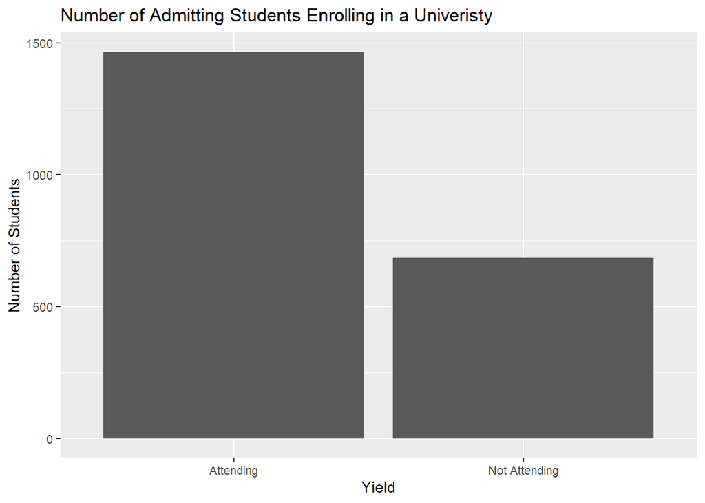

```r
# univariate analysis
ad%>%
  mutate(yield_clean=ifelse(yield==0, "Not Attending", "Attending"))%>%
  ggplot(aes(x=yield_clean))+
  geom_bar()+
  labs(x="Yield",
       y="Number of Students",
       title="Number of Admitting Students Enrolling in a Univeristy")
```

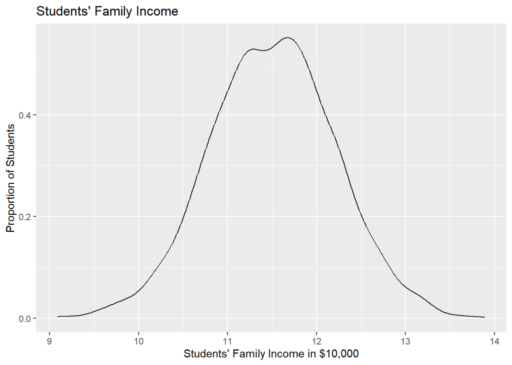

```r
ad%>%
  ggplot(aes(x=log(income)))+
  geom_density()+
  labs(x="Students' Family Income in $10,000",
       y="Proportion of Students",
       title="Students' Family Income")
```

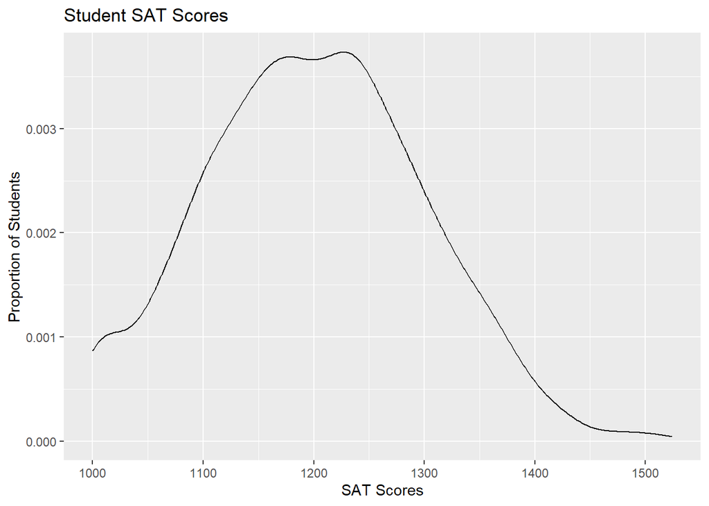

```r
ad%>%
  ggplot(aes(x=sat))+
  geom_density()+
  labs(x="SAT Scores",
       y="Proportion of Students",
       title="Student SAT Scores")
```

```r
# Conditional Variation
```

[output not shown]

> Yield is a binary variable, so I chose a categorical univariate visualization. I did a quick mutate on it so that our graph would look a bit better, swapping out the numerical scaling on the x axis for two simple “attending” and “not attending” labels representative of the 1 and 0 respectively. Income is continuous so I used a density plot– had to log the variable. SAT is also a continuous variable, so I used another density plot.

## Question 2 [2 points]

Look at these same conditional relationships between `yield` and `income` and `sat`, except divide the continuous measures of `income` and `sat` into deciles using the `ntile()` function, and create a single heatmap for all three variables, where the deciles of `income` and `sat` are on the axes, and the tiles are shaded by the average attendance in each cell. Which students are most likely to attend? Which are least likely to attend? Can you determine whether income or SAT scores matter more for attendance based on this plot?

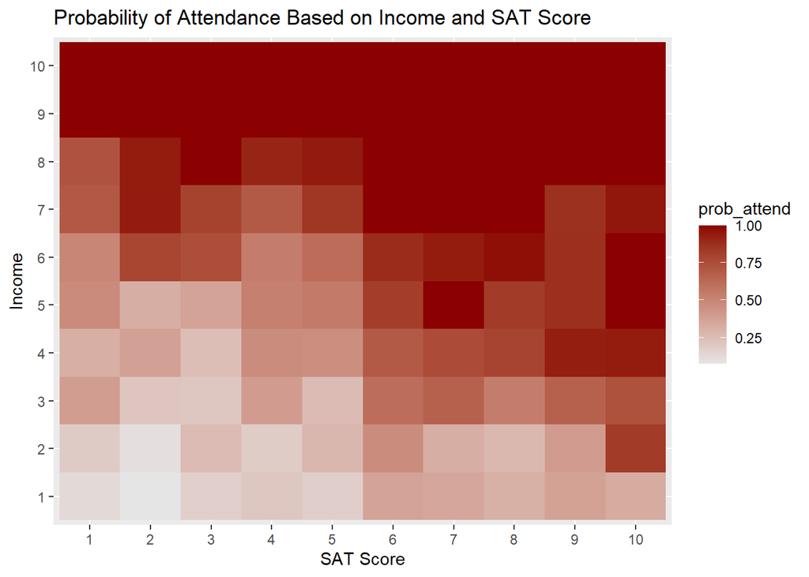

```r
ad %>%
  mutate(sat_dec=ntile(sat, n=10), # calculate deciles for income using the ntile() function
         income_dec=ntile(income, n=10)) %>% # calculate deciles for SAT scores using the ntile() function
  group_by(sat_dec, income_dec) %>% # group_by these two decile variables for income and SAT scores
  summarise(prob_attend=mean(yield)) %>% # calculate the probability of attending
  ggplot(aes(x = factor(sat_dec),y = factor(income_dec) ,fill =prob_attend)) + # Put the deciles on the axes as factors, and fill by the probability of attending
  geom_tile() +
  scale_fill_gradient(low="grey90", high="darkred") + # OPTIONAL: tweak the aesthetics
  labs(title = 'Probability of Attendance Based on Income and SAT Score', # Make sure to add helpful labels!
       x = 'SAT Score',
       y = 'Income')
```

> - Students with higher income and SAT are most likely to attend, with a student’s level of income being a better predictor of their attendance than their SAT score.

## Question 3 [2 points]

Now start with the simplest way of predicting attendance: the conditional mean. As above, calculate deciles for `income` and `sat` called `incomeDec` and `satDec` using the `ntile()` function. Then calculate the average attendance in each cell using `group_by()` and `mutate()`, and finally predict attendance as 1 if the average is greater than 0.5, and 0 otherwise, using an `ifelse()` function. Evaluate the performance in terms of **accuracy**, **sensitivity**, and **specificity**, making sure to clearly define each metric.

```r
ad <- ad %>%
 mutate(incomeDec=ntile(income, n=10), # calculate deciles for income using the ntile() function
         satDec=ntile(sat, n=10)) %>% # calculate deciles for SAT scores using the ntile() function
  group_by(satDec, incomeDec) %>% # group_by these two decile variables for income and SAT scores
  mutate(prob_attend=mean(yield)) %>% # calculate the probability of attending
  mutate(pred_attend=ifelse(prob_attend>.5,1,0)) %>% # calculate the predicted attendance for each student using 0.5 as the threshold
  ungroup()

ad %>%
  group_by(yield) %>% # Calculate total attendees and non-attendees
  mutate(total_attend=n()) %>% # Calculate total attendees and non-attendees
  group_by(yield, pred_attend, total_attend) %>% # Calculate number of students falling into all four groups (pred attend & attend, pred attend & not attend, pred not & attend, pred not & not attend)
  summarise(nStudents=n(), .groups="drop") %>%
  mutate(proportion=nStudents/total_attend) %>% # calculate the proportion of students in each group
  ungroup() %>% # ALWAYS UNGROUP
  mutate(spec=ifelse(yield==0 & pred_attend==0, proportion, NA),
         sens=ifelse(yield==1 & pred_attend==1, proportion, NA),
         accuracy=(535+1255)/2150,
         guess=mean(yield)) # OPTIONAL: calculate overall accuracy within chunk (could just do it manually too)
```

```
## # A tibble: 4 × 9
##   yield pred_attend total_attend nStudents proport…¹   spec   sens accur…² guess
##   <int>       <dbl>        <int>     <int>     <dbl>  <dbl>  <dbl>   <dbl> <dbl>
## 1     0           0          684       535     0.782  0.782 NA       0.833   0.5
## 2     0           1          684       149     0.218 NA     NA       0.833   0.5
## 3     1           0         1466       211     0.144 NA     NA       0.833   0.5
## 4     1           1         1466      1255     0.856 NA      0.856   0.833   0.5
## # … with abbreviated variable names ¹proportion, ²accuracy
```

```r
  #filter(spec, sens) # OPTIONAL: filter to only look at sensitivity and specificity
```

## Question 4 [2 points]

Now predict whether students will attend using a linear regression model (using the `lm()` function) that predicts `yield` as a function of `income` and `sat` (**not** using deciles, just the continuous versions). Calculate **accuracy**, **sensitivity**, and **specificity** from this model where the threshold is again 0.5, and compare to the results from Question 3. Does this model do better?

```r
m1 <- lm(formula=yield~income+sat, data=ad) # Estimate linear regression model

ad %>%
  mutate(pred_attend=ifelse(predict(m1)>.5,1,0)) %>% # Calculate probability of attending based on the predicted regression result
  group_by(yield) %>% # Calculate total attendees and non-attendees
  mutate(total_attend=n()) %>% # Calculate total attendees and non-attendees
  group_by(yield,pred_attend, total_attend) %>% # Calculate number of students falling into all four groups (pred attend & attend, pred attend & not attend, pred not & attend, pred not & not attend)
  summarise(nStudents=n(),.groups="drop") %>%
  mutate(proportion=nStudents/total_attend) %>% # calculate the proportion of students in each group
  ungroup() %>% # ALWAYS UNGROUP
  mutate(sensitivity=ifelse(yield==1&pred_attend==1, proportion,NA),
         specificity=ifelse(yield==0&pred_attend==0, proportion,NA),
         accuracy=(366+1345)/2150)%>% # OPTIONAL: calculate overall accuracy within chunk (could just do it manually too)
  select(sensitivity, specificity, accuracy) # OPTIONAL: filter to only look at sensitivity and specificity
```

```
## # A tibble: 4 × 3
##   sensitivity specificity accuracy
##         <dbl>       <dbl>    <dbl>
## 1      NA           0.535    0.796
## 2      NA          NA        0.796
## 3      NA          NA        0.796
## 4       0.917      NA        0.796
```

> - The model that uses linear regression performs slightly worse than the model from before. We lose ~4 percentage points of accuracy, gaining 6 percentage points in sensitivity but losing a substantial portion of specificity.